# tidytext Example

```r
setwd("~/GitHub/MachineLearning/Models/NLP_TextMining/")
if(!require(easypackages)){install.packages("easypackages")}
library(easypackages)
packages("tidyverse","gutenbergr", "tidytext", "triebeard", prompt = FALSE)

#devtools::install_github('cttobin/ggthemr')
library(ggthemr)
```

> Introduces `ggthemr` - a great package for professional ggplot

# Introduction

Perform a text mining analysis of two philosophical works on the topic of individual liberty: John Locke’s *Second Treatise of Goverenment* and John Stuart Mill’s *On Liberty*.

# A brief excursion into political philosophy

*Second Treatise of Government* was published in 1690, while *On Liberty* was published 1859. Both of these influential works are ostensibly about individual freedom. However, they are nonetheless different in important ways.

First, while *Second Treatise* is predominantly about civil liberty, or freedom from tyrannical forms of government that infringe upon individual rights to life, liberty, and property, *On Liberty* mainly focuses on personal liberty, i.e., freedom of speech/thought and social non-conformity.

Second, the two authors differed fundamentally in their view of natural rights.

- Locke argued that natural law gives all people universal and unalienable rights of self-ownership and self-determination, and that the purpose of government is to protect these rights.
- Mill did not believe in the logical existence of natural rights, and therefore made his defense of individual liberty from the standpoint of utilitarianism, or the greatest happiness for the greatest number.

Based on these differences, you might expect word usage to differ somewhat between *Second Treatise* and *On Liberty*.

# Tidytext

Project Gutenberg has *Second Treatise of Government* and *On Liberty* in its free digital archives. Uese `gutenbergr` to download the works.

```r
# set plot theme
ggthemr("dust")
```

Use the metadata file from `gutenbergr` to find the ID numbers for *Second Treatise* and *On Liberty*.

## Locke.

```r
# Download Second Treatise of Governement
locke <- gutenberg_download(gutenberg_id = 7370)

# Show a selection of text
locke %>% select(text) %>% slice(50:56)
```

```
## # A tibble: 7 x 1
##   text
##   <chr>
## 1 Reader, thou hast here the beginning and end of a discourse concerning
## 2 government; what fate has otherwise disposed of the papers that should
## 3 have filled up the middle, and were more than all the rest, it is not
## 4 worth while to tell thee. These, which remain, I hope are sufficient to
## 5 establish the throne of our great restorer, our present King William; to
## 6 make good his title, in the consent of the people, which being the only
## 7 one of all lawful governments, he has more fully and clearly, than any
```

```r
# Tokenize text and remove stop words
tidy_locke <- locke %>%
  unnest_tokens(output = word, input = text, token = "words") %>%
  anti_join(stop_words) %>%
  mutate(word = str_extract(word, "[a-z']+"))
# Show a selection of tokens (words)
tidy_locke %>% select(word) %>% slice(144:170)
```

```
## # A tibble: 27 x 1
##    word
##    <chr>
##  1 reader
##  2 thou
##  3 hast
##  4 beginning
##  5 discourse
##  6 government
##  7 fate
##  8 disposed
##  9 papers
## 10 filled
## # ... with 17 more rows
```

The sentences have been broken up, or tokenized, into seperate words, and the stop words (here, the, and, etc.) have been removed.

A few notes about the code in the chunk above:

- there are many other options in the *tidytext::unnest_tokens* function, including characters, sentences, and paragraphs.
- used *stringr::str_extract* function (as suggested in Text Mining with R) to change the output of `unnest_tokens` to include only actual words, and no numbers. Because, counterintuitively, token = “words” can also return numbers.

## On Liberty.

```r
# Download On Liberty
mill <- gutenberg_download(gutenberg_id = 34901)

# Tokenize text and remove stop words
tidy_mill <- mill %>%
  unnest_tokens(output = word, input = text, token = "words") %>%
  anti_join(stop_words) %>% mutate(word = str_extract(word, "[a-z']+"))
```

Now that we have two tidy data frames of words from each text, we can make some charts of word frequency to see how different Locke and Mill were with regard to word choice.

## Visualizing word frequencies

Plot the top 10 most frequently used words by John Locke in *Second Treatise*.

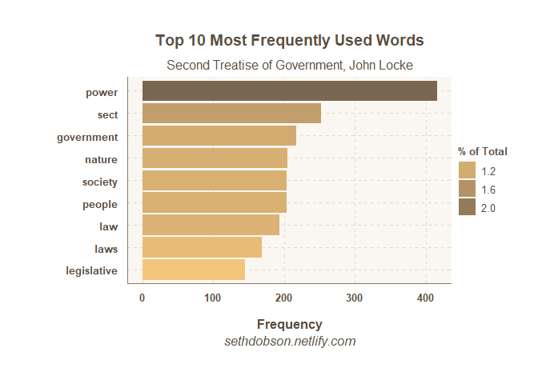

```r
# Calculate word counts and percentages
tidy_locke_n <- tidy_locke %>% count(word, sort = TRUE)%>% mutate(pct = n/sum(n))

# Plot word frequencies
tidy_locke_n %>%
  top_n(10, n) %>%
  filter(word != "NA") %>%
  ggplot(aes(x = reorder(word, n), y = n)) +
  geom_col(aes(fill = pct*100)) +
  coord_flip() +
  labs(title = "Top 10 Most Frequently Used Words",
       subtitle = "Second Treatise of Government, John Locke",
       x = "",
       y = "Frequency",
       caption = "sethdobson.netlify.com") +
  theme(plot.caption = element_text(face = "italic")) +
  scale_fill_continuous("% of Total")
```

By far the most frequently used word is *power*, which represents ~2% of all words. Other words in the top 10 reflect Locke’s focus on the proper role of government in people’s lives and his emphasis on natural law.

Plot the top 10 most frequently used words in *On Liberty*.

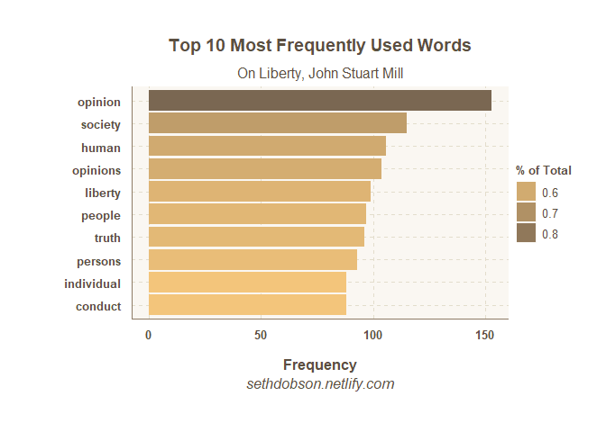

```r
# Calculate word counts and percentages
tidy_mill_n <- tidy_mill %>% count(word, sort = TRUE) %>% mutate(pct = n/sum(n))

# Plot word frequencies
tidy_mill_n %>%
  top_n(10, n) %>%
  filter(word != "NA") %>%
  ggplot(aes(x = reorder(word, n),y = n)) +
  geom_col(aes(fill = pct*100)) +
  coord_flip() +
  labs(title = "Top 10 Most Frequently Used Words",
       subtitle = "On Liberty, John Stuart Mill",
       x = "",
       y = "Frequency",
       caption = "sethdobson.netlify.com") +
  theme(plot.caption = element_text(face = "italic")) +
  scale_fill_continuous("% of Total")
```

```r
# Calculate the summed percentage of "opinion" and "opinions"
tidy_mill_n %>% filter(word %in% c("opinion", "opinoins")) %>% summarise(sum_pct = sum(pct)*100)
```

```
## # A tibble: 1 x 1
##   sum_pct
##     <dbl>
## 1   0.871
```

If we combine both data sets into one data frame, we can look at the correlation between the frequencies for all the words. To do this, we need to join the word frequencies from *Second Treatise* with *On Liberty*.

Use `dplyr::full_join` function to get the full set of words across both books. The trick is to then use `dplyr::replace_na` to make all missing words have a value of 0.

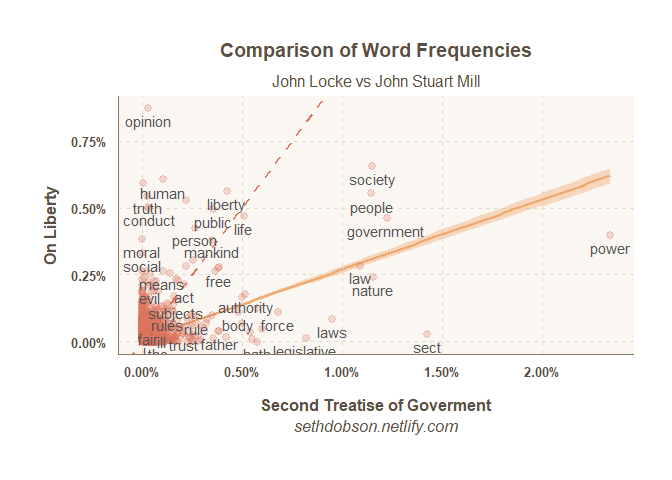

```r
# Combine word frequency data frames
tidy_both_n <- tidy_locke_n %>%
  select(word, n, pct) %>%
  rename(n_locke = n, pct_locke = pct) %>%
  full_join(y = tidy_mill_n, by = "word") %>%
  rename(pct_mill = pct, n_mill = n) %>%
  replace_na(list(n_locke = 0, pct_locke = 0, pct_mill = 0, n_mill = 0))

# Plot combined frequencies for all words
tidy_both_n %>%
  filter(word != "NA") %>%
  ggplot(aes(x = pct_locke, y = pct_mill, label = word)) +
  geom_abline(intercept = 0, slope = 1, lty = 2, lwd = 1.05) +
  stat_smooth(method = lm) +
  geom_jitter(alpha = 0.25, size = 2.5) +
  geom_text(aes(label = word), check_overlap = TRUE, vjust = 1.5) +
  scale_x_continuous(labels = scales::percent_format(accuracy = .05)) +
  scale_y_continuous(labels = scales::percent_format(accuracy = .05)) +
  labs(title = "Comparison of Word Frequencies",
       subtitle = "John Locke vs John Stuart Mill",
       x = "Second Treatise of Goverment",
       y = "On Liberty",
       caption = "sethdobson.netlify.com") +
  theme(plot.caption = element_text(face = "italic"))
```

There is a positive correlation between the word frequencies overall, as indicated by the linear regression line having a $slope > 0 (Pearson’s r = 0.448)$.

Most of the most frequently used words in each book fall far from the line.

There is a small set of words that each author uses relatively frequently that also show similar percentages. This set includes the words *liberty*, *life*, *public*, *person*, *mankind* and *free.*

# Reference

https://sethdobson.netlify.com/2019/07/24/visualizing-locke-and-mill-a-tidytext-analysis/